# **Bitcoin Forecasting using ARIMA Model**

by Houssam FOUKI - houssam.fouki@student-cs.fr

```python
import numpy as np # linear algebra
import pandas as pd # data processing, CSV file I/O (e.g. pd.read_csv)
import seaborn; seaborn.set()
from sklearn.metrics import mean_squared_error

import matplotlib.pylab as plt
%matplotlib inline

from matplotlib.pylab import rcParams
rcParams['figure.figsize'] = 15,6
from statsmodels.tsa.stattools import adfuller
from statsmodels.tsa.seasonal import seasonal_decompose
from statsmodels.tsa.stattools import acf, pacf
from statsmodels.tsa.arima_model import ARIMA
```

```python
import warnings
warnings.filterwarnings("ignore")
```

**Loading Data and study the rows and column values**

```python
data = pd.read_csv("bitcoin_price_Training - Training.csv")
print(data.head(5))
print(data.tail(5))
data.dtypes
data.info()
data.describe()
```

```
           Date     Open     High      Low    Close         Volume  \
0  Jul 31, 2017  2763.24  2889.62  2720.61  2875.34    860,575,000
1  Jul 30, 2017  2724.39  2758.53  2644.85  2757.18    705,943,000
2  Jul 29, 2017  2807.02  2808.76  2692.80  2726.45    803,746,000
3  Jul 28, 2017  2679.73  2897.45  2679.73  2809.01  1,380,100,000
4  Jul 27, 2017  2538.71  2693.32  2529.34  2671.78    789,104,000

       Market Cap
0  45,535,800,000
1  44,890,700,000
2  46,246,700,000
3  44,144,400,000
4  41,816,500,000
              Date    Open    High     Low   Close Volume     Market Cap
1551  May 02, 2013  116.38  125.60   92.28  105.21      -  1,292,190,000
1552  May 01, 2013  139.00  139.89  107.72  116.99      -  1,542,820,000
1553  Apr 30, 2013  144.00  146.93  134.05  139.00      -  1,597,780,000
1554  Apr 29, 2013  134.44  147.49  134.00  144.54      -  1,491,160,000
1555  Apr 28, 2013  135.30  135.98  132.10  134.21      -  1,500,520,000
<class 'pandas.core.frame.DataFrame'>
RangeIndex: 1556 entries, 0 to 1555
Data columns (total 7 columns):
Date          1556 non-null object
Open          1556 non-null float64
High          1556 non-null float64
Low           1556 non-null float64
Close         1556 non-null float64
Volume        1556 non-null object
Market Cap    1556 non-null object
dtypes: float64(4), object(3)
memory usage: 85.2+ KB
```

|  | Open | High | Low | Close |
| --- | --- | --- | --- | --- |
| count | 1556.000000 | 1556.000000 | 1556.000000 | 1556.000000 |
| mean | 582.625328 | 597.992847 | 567.851446 | 584.239396 |
| std | 523.137312 | 542.992855 | 505.877401 | 525.904442 |
| min | 68.500000 | 74.560000 | 65.530000 | 68.430000 |
| 25% | 254.287500 | 260.327500 | 248.835000 | 254.320000 |
| 50% | 438.600000 | 447.560000 | 430.570000 | 438.855000 |
| 75% | 662.437500 | 674.525000 | 646.735000 | 663.402500 |
| max | 2953.220000 | 2999.910000 | 2840.530000 | 2958.110000 |

```python
# Set date do Date-time format in order to perform time series study also set it as index of dataFrame.

data = pd.read_csv("bitcoin_price_Training - Training.csv",index_col= 'Date')
print(data.head(5))
data.info()
data.index = pd.to_datetime(data.index)
print(data.index)
data.head(5)
```

```
                 Open     High      Low    Close         Volume  \
Date
Jul 31, 2017  2763.24  2889.62  2720.61  2875.34    860,575,000
Jul 30, 2017  2724.39  2758.53  2644.85  2757.18    705,943,000
Jul 29, 2017  2807.02  2808.76  2692.80  2726.45    803,746,000
Jul 28, 2017  2679.73  2897.45  2679.73  2809.01  1,380,100,000
Jul 27, 2017  2538.71  2693.32  2529.34  2671.78    789,104,000

                  Market Cap
Date
Jul 31, 2017  45,535,800,000
Jul 30, 2017  44,890,700,000
Jul 29, 2017  46,246,700,000
Jul 28, 2017  44,144,400,000
Jul 27, 2017  41,816,500,000
<class 'pandas.core.frame.DataFrame'>
Index: 1556 entries, Jul 31, 2017 to Apr 28, 2013
Data columns (total 6 columns):
Open          1556 non-null float64
High          1556 non-null float64
Low           1556 non-null float64
Close         1556 non-null float64
Volume        1556 non-null object
Market Cap    1556 non-null object
dtypes: float64(4), object(2)
memory usage: 85.1+ KB
DatetimeIndex(['2017-07-31', '2017-07-30', '2017-07-29', '2017-07-28',
               '2017-07-27', '2017-07-26', '2017-07-25', '2017-07-24',
               '2017-07-23', '2017-07-22',
               ...
               '2013-05-07', '2013-05-06', '2013-05-05', '2013-05-04',
               '2013-05-03', '2013-05-02', '2013-05-01', '2013-04-30',
               '2013-04-29', '2013-04-28'],
              dtype='datetime64[ns]', name='Date', length=1556, freq=None)
```

| Date | Open | High | Low | Close | Volume | Market Cap |
| --- | --- | --- | --- | --- | --- | --- |
| 2017-07-31 | 2763.24 | 2889.62 | 2720.61 | 2875.34 | 860,575,000 | 45,535,800,000 |
| 2017-07-30 | 2724.39 | 2758.53 | 2644.85 | 2757.18 | 705,943,000 | 44,890,700,000 |
| 2017-07-29 | 2807.02 | 2808.76 | 2692.80 | 2726.45 | 803,746,000 | 46,246,700,000 |
| 2017-07-28 | 2679.73 | 2897.45 | 2679.73 | 2809.01 | 1,380,100,000 | 44,144,400,000 |
| 2017-07-27 | 2538.71 | 2693.32 | 2529.34 | 2671.78 | 789,104,000 | 41,816,500,000 |

```python
# Sort the dataset from oldest - recent

data = data.sort_index()
data.head()
```

| Date | Open | High | Low | Close | Volume | Market Cap |
| --- | --- | --- | --- | --- | --- | --- |
| 2013-04-28 | 135.30 | 135.98 | 132.10 | 134.21 | - | 1,500,520,000 |
| 2013-04-29 | 134.44 | 147.49 | 134.00 | 144.54 | - | 1,491,160,000 |
| 2013-04-30 | 144.00 | 146.93 | 134.05 | 139.00 | - | 1,597,780,000 |
| 2013-05-01 | 139.00 | 139.89 | 107.72 | 116.99 | - | 1,542,820,000 |
| 2013-05-02 | 116.38 | 125.60 | 92.28 | 105.21 | - | 1,292,190,000 |

```
Text(0,0.5,'Daily Bitcoin price')
```

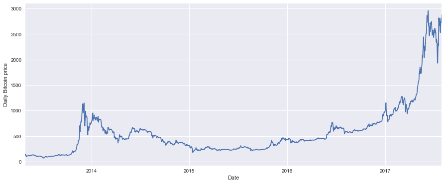

```python
data['Close'].plot()
plt.ylabel("Daily Bitcoin price")
```

```python
 # Initial prediction will be focused around closing price of Bitcoin.

data = data['Close']
```

```
Text(0,0.5,'Weekly bitcoin price')
```

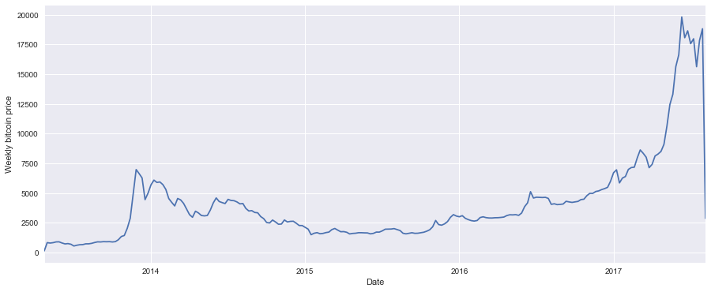

```python
# Resample the time scale by week and sum closing values.

weekly = data.resample('W').sum()
weekly.plot()
plt.ylabel('Weekly bitcoin price')
```

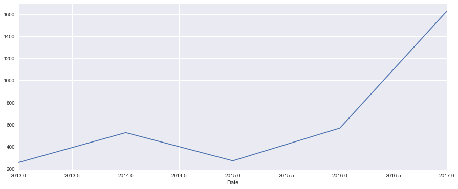

```python
# Group by year & average the data

by_year = data.groupby(data.index.year).mean()
by_year.plot()
```

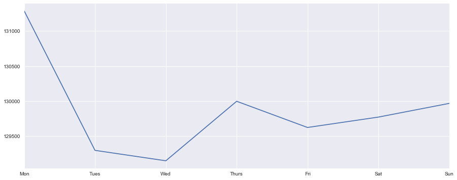

```python
# Group by weekdays & sum the data sample

by_weekday = data.groupby(data.index.dayofweek).sum()
by_weekday.index = ['Mon', 'Tues', 'Wed', 'Thurs', 'Fri', 'Sat', 'Sun']
by_weekday.plot()
```

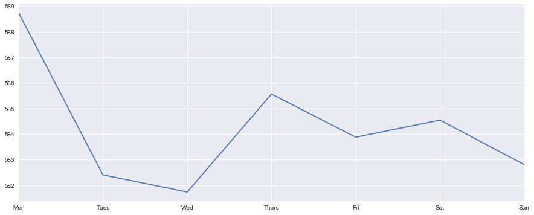

```python
# Group by weekdays & average the data sample

by_weekday = data.groupby(data.index.dayofweek).mean()
by_weekday.index = ['Mon', 'Tues', 'Wed', 'Thurs', 'Fri', 'Sat', 'Sun']
by_weekday.plot()
```

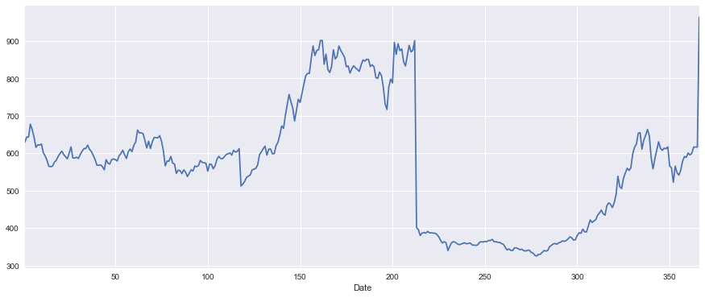

```python
# Group by day & average the data sample

by_day = data.groupby(data.index.dayofyear).mean()
by_day.plot()
```

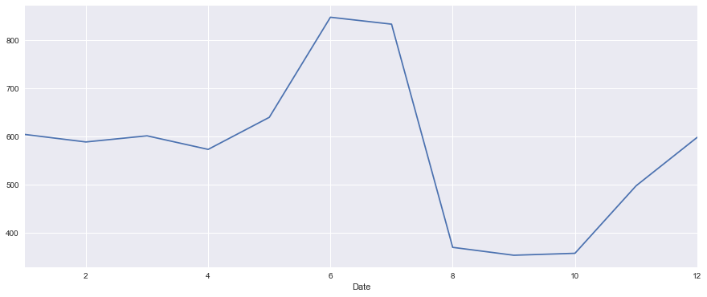

```python
# Group by month & average the data sample

by_month = data.groupby(data.index.month).mean()
by_month.plot()
```

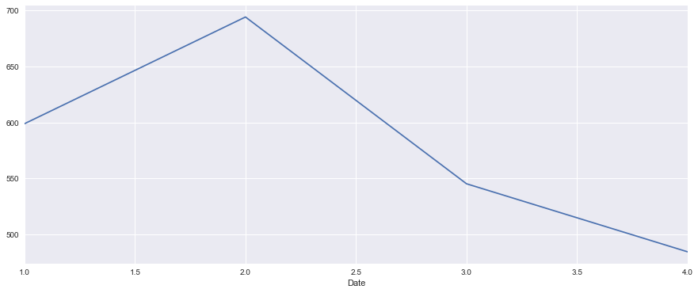

```python
# Group by quarter & average the data sample

by_quarter = data.groupby(data.index.quarter).mean()
by_quarter.plot()
```

```
Date
1    AxesSubplot(0.125,0.2;0.775x0.68)
2    AxesSubplot(0.125,0.2;0.775x0.68)
3    AxesSubplot(0.125,0.2;0.775x0.68)
4    AxesSubplot(0.125,0.2;0.775x0.68)
Name: Close, dtype: object
```

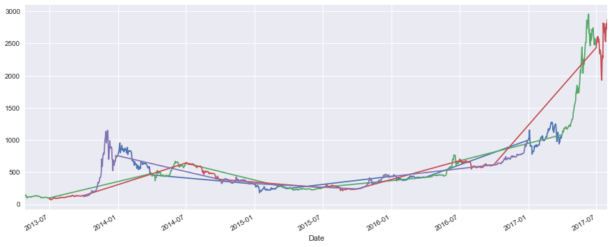

```python
by_quarter = data.groupby(data.index.quarter)
by_quarter.plot()
```

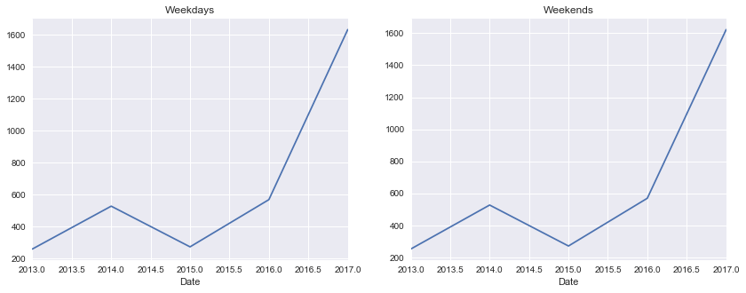

```python
# Weekdays vs Weekend per year average

weekend = np.where(data.index.weekday < 5, 'Weekday', 'Weekend')
by_time = data.groupby([weekend, data.index.year]).mean()
fig, ax = plt.subplots(1, 2, figsize=(14, 5))
by_time.loc['Weekday'].plot(ax=ax[0], title='Weekdays')
by_time.loc['Weekend'].plot(ax=ax[1], title='Weekends')
```

```python
ts = data
```

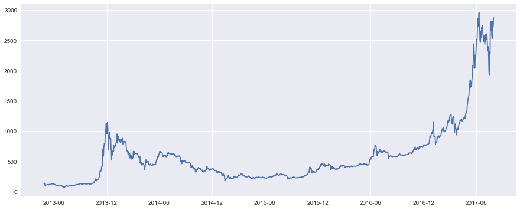

```python
plt.plot(ts)
```

This part is inspired by: https://www.analyticsvidhya.com/blog/2016/02/time-series-forecasting-codes-python/

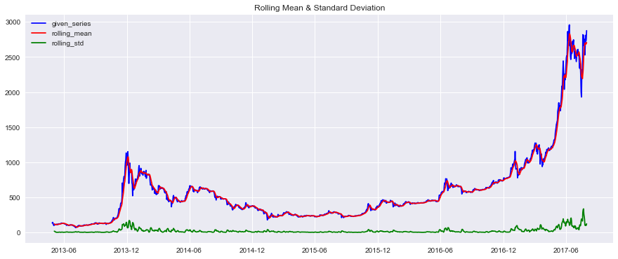

```
Results of Dickey-Fuller Test:
Test Statistic                    2.535589
p-value                           0.999060
#Lags Used                       24.000000
Number of Observations Used    1531.000000
Critical Value (1%)              -3.434628
Critical Value (5%)              -2.863430
Critical Value (10%)             -2.567776
dtype: float64
```

```python
from statsmodels.tsa.stattools import adfuller
def test_for_stationary(input_data):
    r_mean = input_data.rolling(window = 7,center=False).mean()
    r_std = input_data.rolling(window = 7,center=False).std()

    # plotting the data
    given = plt.plot(input_data, color = 'blue', label = 'given_series')
    rolling_mean = plt.plot(r_mean, color = 'red', label = 'rolling_mean')
    rolling_std = plt.plot(r_std, color ='green', label = 'rolling_std')
    plt.legend(loc = 'best')
    plt.title('Rolling Mean & Standard Deviation')
    plt.show(block=False)

     #Perform Dickey-Fuller test:
    print('Results of Dickey-Fuller Test:')
    dftest = adfuller(input_data)
    dfoutput = pd.Series(dftest[0:4], index=['Test Statistic','p-value','#Lags Used','Number of Observations Used'])
    for key,value in dftest[4].items():
        dfoutput['Critical Value (%s)'%key] = value
    print(dfoutput)

test_for_stationary(ts)
```

### The test statistic is very large compared to the crtical value. The above series show that rolling mean value varies with time and is not stationary. The series needs to be Stationarized. we need to eliminate the trend and seasonality from the series to make it stationary

```python
# Transforming the data - (to eliminate trend)
```

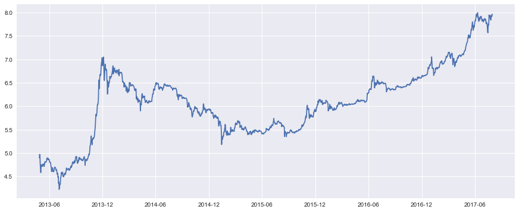

```python
# Apply log funtion to data.

ts_logtransformed = np.log(ts)
plt.plot(ts_logtransformed)
```

```python
ts_logtransformed.head(10)
```

```
Date
2013-04-28    4.899406
2013-04-29    4.973556
2013-04-30    4.934474
2013-05-01    4.762088
2013-05-02    4.655958
2013-05-03    4.582413
2013-05-04    4.722953
2013-05-05    4.752814
2013-05-06    4.721174
2013-05-07    4.714025
Name: Close, dtype: float64
```

# Smoothing by Rolling average

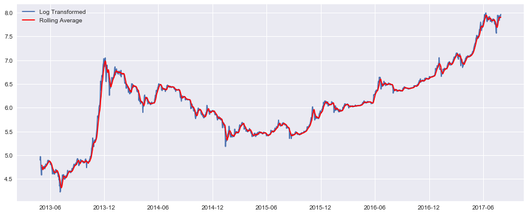

```python
# Apply rolling avg + log funtion to data.

Rolling_average = ts_logtransformed.rolling(window = 7, center= False).mean()
plt.plot(ts_logtransformed, label = 'Log Transformed')
plt.plot(Rolling_average, color = 'red', label = 'Rolling Average')
plt.legend(loc = 'best')
```

```python
Rolling_average.head(10)
```

```
Date
2013-04-28         NaN
2013-04-29         NaN
2013-04-30         NaN
2013-05-01         NaN
2013-05-02         NaN
2013-05-03         NaN
2013-05-04    4.790121
2013-05-05    4.769180
2013-05-06    4.733125
2013-05-07    4.701632
Name: Close, dtype: float64
```

Lets subtract this Rolling average this from the original log transfomred series.

```python
# subtract log - log rolling avg

log_Rolling_difference = ts_logtransformed - Rolling_average
log_Rolling_difference.head(10)
log_Rolling_difference.tail(10)
```

```
Date
2017-07-22    0.151593
2017-07-23    0.073239
2017-07-24    0.051861
2017-07-25   -0.030130
2017-07-26   -0.063797
2017-07-27   -0.001463
2017-07-28    0.041254
2017-07-29    0.015741
2017-07-30    0.025554
2017-07-31    0.061402
Name: Close, dtype: float64
```

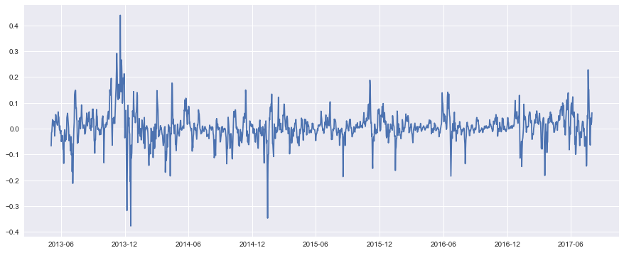

```python
#  Replace NAN with 0 in the above dataframe to avoid any errors in the future.

log_Rolling_difference.dropna(inplace=True)
plt.plot(log_Rolling_difference)
```

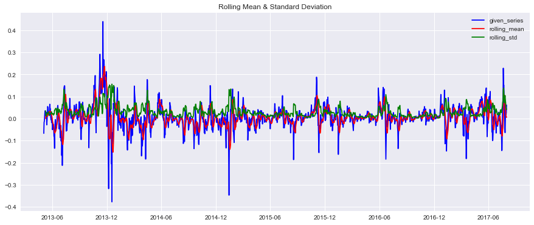

```
Results of Dickey-Fuller Test:
Test Statistic                -7.191326e+00
p-value                        2.499260e-10
#Lags Used                     2.200000e+01
Number of Observations Used    1.527000e+03
Critical Value (1%)           -3.434640e+00
Critical Value (5%)           -2.863435e+00
Critical Value (10%)          -2.567779e+00
dtype: float64
```

```python
test_for_stationary(log_Rolling_difference)
```

Use exponential_weighted_moving_average instead of moving average to improve the solution

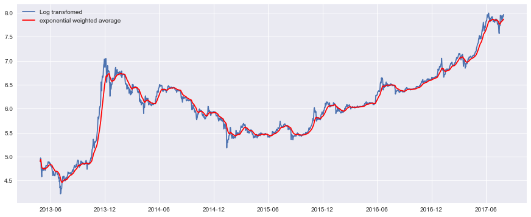

```python
# Use exponential_weighted_moving_average instead of moving average to improve the solution

expwighted_avg = ts_logtransformed.ewm(halflife=7,min_periods=0,adjust=True,ignore_na=False).mean()
plt.plot(ts_logtransformed, label = 'Log transfomed')
plt.plot(expwighted_avg, color='red', label = 'exponential weighted average')
plt.legend(loc = 'best')
```

```python
expwighted_avg.head(10)
```

```
Date
2013-04-28    4.899406
2013-04-29    4.938315
2013-04-30    4.936906
2013-05-01    4.886513
2013-05-02    4.830850
2013-05-03    4.778564
2013-05-04    4.768079
2013-05-05    4.765448
2013-05-06    4.758372
2013-05-07    4.751720
Name: Close, dtype: float64
```

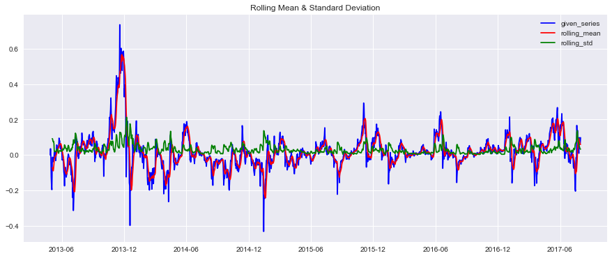

```
Results of Dickey-Fuller Test:
Test Statistic                   -5.442038
p-value                           0.000003
#Lags Used                       23.000000
Number of Observations Used    1532.000000
Critical Value (1%)              -3.434626
Critical Value (5%)              -2.863428
Critical Value (10%)             -2.567775
dtype: float64
```

```python
log_expmovwt_diff = ts_logtransformed - expwighted_avg

test_for_stationary(log_expmovwt_diff)
```

Now the current time series is stationary,the TS (test_statistic) value is less than 1% critcal value. Since weights are assigned to values from the starting index. Therefore the test works

Few other methods to eliminate Trend and seasonality. Here i am implementing Differencing and Decompostion

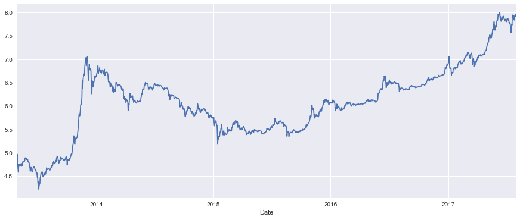

```python
ts_logtransformed.plot()
```

## Seasonality Adjustment by Differencing

Seasonal components in a Time series can be elimnated by using differencing. If there is a seasonal component at level of one month, then it can be removed on an observation today by substracting the value from last month (Ex: Value(Oct 1)-Value(sep 1), value (oct 2 - Value(Sep 2),.....) We can substract last months data to the presents (giving a gap of 30 days) and first months data would not be available for modeling

I am trying to difference different types of seasonality and test for statioanarized data

```
Date
2013-04-28         NaN
2013-04-29         NaN
2013-04-30         NaN
2013-05-01         NaN
2013-05-02         NaN
2013-05-03         NaN
2013-05-04         NaN
2013-05-05   -0.146592
2013-05-06   -0.252382
2013-05-07   -0.220449
Name: Close, dtype: float64
```

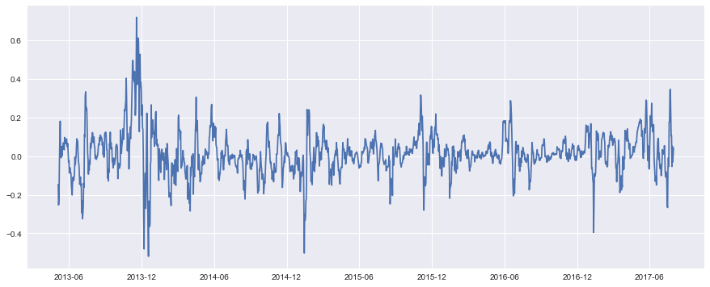

```python
ts_diff_logtrans = ts_logtransformed -ts_logtransformed.shift(7)
plt.plot(ts_diff_logtrans)
ts_diff_logtrans.head(10)
```

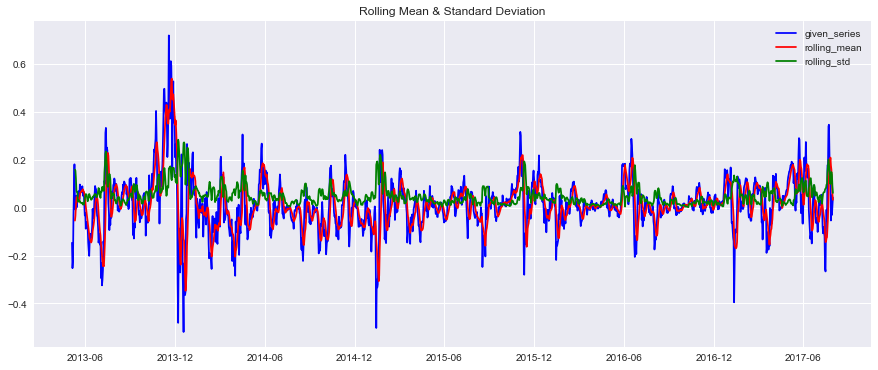

```
Results of Dickey-Fuller Test:
Test Statistic                -6.523574e+00
p-value                        1.027774e-08
#Lags Used                     2.300000e+01
Number of Observations Used    1.525000e+03
Critical Value (1%)           -3.434645e+00
Critical Value (5%)           -2.863437e+00
Critical Value (10%)          -2.567780e+00
dtype: float64
```

```python
ts_diff_logtrans.dropna(inplace=True)
test_for_stationary(ts_diff_logtrans)
```

The Dickey-Fuller test statis is very much less than 1% criticasl value than in the previous case. We can say that the Time series is stationary with 99% confidence

## Decomposing

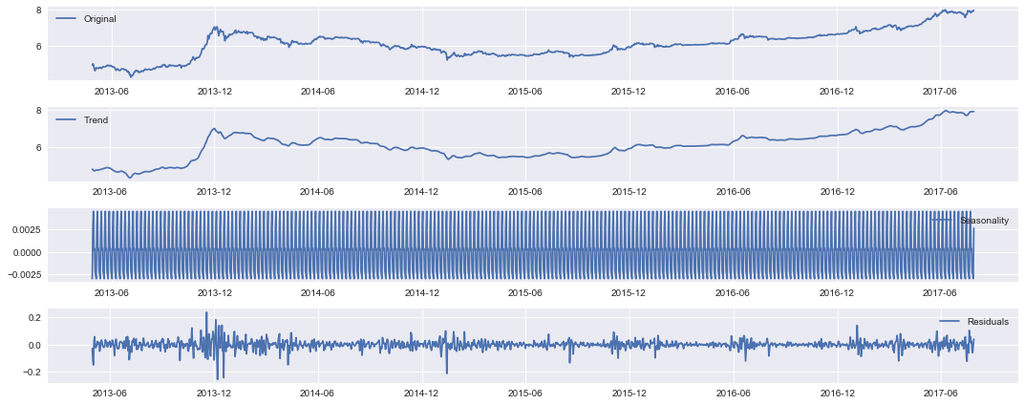

```python
decomposition = seasonal_decompose(ts_logtransformed)

trend = decomposition.trend
seasonal = decomposition.seasonal
residual = decomposition.resid

plt.subplot(411)
plt.plot(ts_logtransformed, label='Original')
plt.legend(loc='best')
plt.subplot(412)
plt.plot(trend, label='Trend')
plt.legend(loc='best')
plt.subplot(413)
plt.plot(seasonal,label='Seasonality')
plt.legend(loc='best')
plt.subplot(414)
plt.plot(residual, label='Residuals')
plt.legend(loc='best')
plt.tight_layout()
```

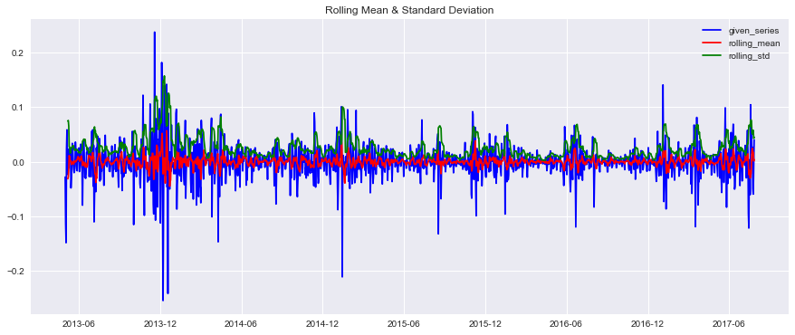

```
Results of Dickey-Fuller Test:
Test Statistic                -1.256779e+01
p-value                        2.035387e-23
#Lags Used                     2.300000e+01
Number of Observations Used    1.526000e+03
Critical Value (1%)           -3.434642e+00
Critical Value (5%)           -2.863436e+00
Critical Value (10%)          -2.567779e+00
dtype: float64
```

```python
decomposed_TS = residual
decomposed_TS.dropna(inplace=True)
test_for_stationary(decomposed_TS)
```

# Forecasting

```python
#ACF and PACF plots:
lag_acf = acf(ts_diff_logtrans, nlags=30)
lag_pacf = pacf(ts_diff_logtrans, nlags=50, method='ols')
```

```
Text(0.5,1,'Autocorrelation Function')
```

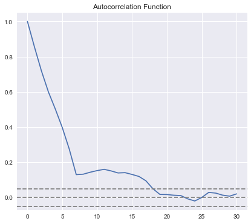

```python
#Plot ACF:
plt.subplot(121)
plt.plot(lag_acf)
plt.axhline(y=0,linestyle='--',color='gray')
plt.axhline(y=-1.96/np.sqrt(len(ts_diff_logtrans)),linestyle='--',color='gray')
plt.axhline(y=1.96/np.sqrt(len(ts_diff_logtrans)),linestyle='--',color='gray')
plt.title('Autocorrelation Function')
```

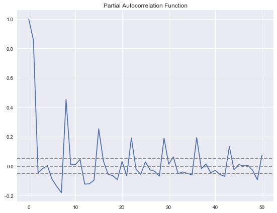

```python
#Plot PACF:
plt.subplot(122)
plt.plot(lag_pacf)
plt.axhline(y=0,linestyle='--',color='gray')
plt.axhline(y=-1.96/np.sqrt(len(ts_diff_logtrans)),linestyle='--',color='gray')
plt.axhline(y=1.96/np.sqrt(len(ts_diff_logtrans)),linestyle='--',color='gray')
plt.title('Partial Autocorrelation Function')
plt.tight_layout()
```

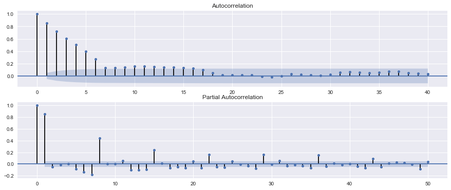

```python
from statsmodels.graphics.tsaplots import plot_acf
from statsmodels.graphics.tsaplots import plot_pacf
from matplotlib import pyplot
pyplot.figure()
pyplot.subplot(211)
plot_acf(ts_diff_logtrans, ax=pyplot.gca(),lags=40)
pyplot.subplot(212)
plot_pacf(ts_diff_logtrans, ax=pyplot.gca(), lags=50)
pyplot.show()
```

Below are some observations from the plots.

In this plot, the two dotted lines on either sides of 0 are the confidence interevals. These can be used to determine the ‘p’ and ‘q’ values as: the Lag values are identified from PACF and ACF plots for Autoregression(AR) and Moving Average(MA) parameters, p and q respectively p – The lag value where the PACF chart crosses the upper confidence interval for the first time. If you notice closely, in this case p=2, The PACF shows a significant lag on day 2

q – The lag value where the ACF chart crosses the upper confidence interval for the first time. If you notice closely, in this case q=18, since the ACF shows a significant lag for 18th day.

The PACF perhaps has some significant lag at 7th, 8th, 12th, 15th day and so on, which also suggests that there is still some seasonality present in the differenced data. We will try different orders of ARIMA models to identify the best order by deriving the residual sum of squares(RSS) for each model. Lower RSS are considered to be the best ones

```python
from statsmodels.tsa.arima_model import ARIMA
```

```python
ts_diff_logtrans = ts_diff_logtrans.fillna(0)
```

# AR Model

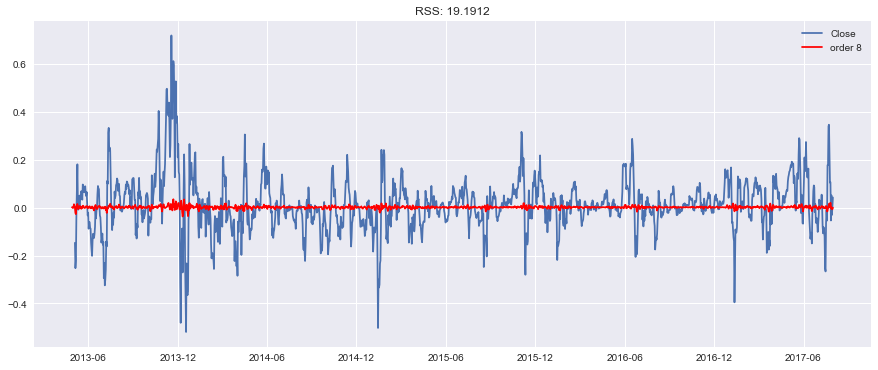

```python
model = ARIMA(ts_logtransformed, order=(8, 1, 0))
results_AR = model.fit(disp=-1)
plt.plot(ts_diff_logtrans)
plt.plot(results_AR.fittedvalues, color='red', label = 'order 8')
RSS = results_AR.fittedvalues-ts_diff_logtrans
RSS.dropna(inplace=True)
plt.title('RSS: %.4f'% sum(RSS**2))
plt.legend(loc = 'best')
```

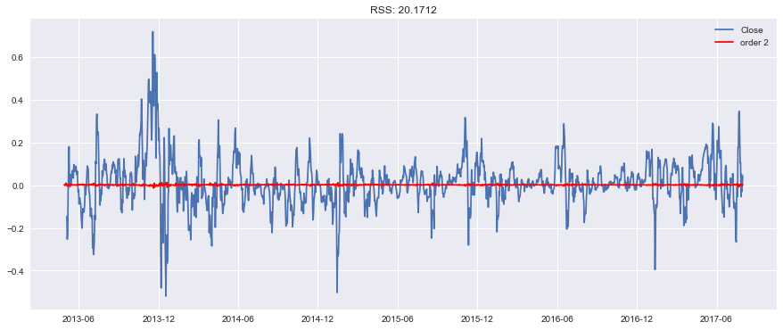

```python
model = ARIMA(ts_logtransformed, order=(2, 1, 0))
results_AR = model.fit(disp=-1)
plt.plot(ts_diff_logtrans)
plt.plot(results_AR.fittedvalues, color='red', label = 'order 2')
RSS = results_AR.fittedvalues-ts_diff_logtrans
RSS.dropna(inplace=True)
plt.title('RSS: %.4f'% sum(RSS**2))
plt.legend(loc ='best')
```

```python
print(results_AR.summary())
```

```
                             ARIMA Model Results
==============================================================================
Dep. Variable:                D.Close   No. Observations:                 1555
Model:                 ARIMA(2, 1, 0)   Log Likelihood                2704.690
Method:                       css-mle   S.D. of innovations              0.042
Date:                Wed, 07 Feb 2018   AIC                          -5401.380
Time:                        07:36:44   BIC                          -5379.984
Sample:                    04-29-2013   HQIC                         -5393.424
                         - 07-31-2017
=================================================================================
                    coef    std err          z      P>|z|      [0.025      0.975]
---------------------------------------------------------------------------------
const             0.0020      0.001      1.908      0.057   -5.37e-05       0.004
ar.L1.D.Close    -0.0011      0.025     -0.044      0.965      -0.051       0.049
ar.L2.D.Close    -0.0435      0.025     -1.715      0.086      -0.093       0.006
                                    Roots
=============================================================================
                 Real           Imaginary           Modulus         Frequency
-----------------------------------------------------------------------------
AR.1           -0.0127           -4.7948j            4.7948           -0.2504
AR.2           -0.0127           +4.7948j            4.7948            0.2504
-----------------------------------------------------------------------------
```

# MA model

```
Text(0.5,1,'RSS: 19.0817')
```

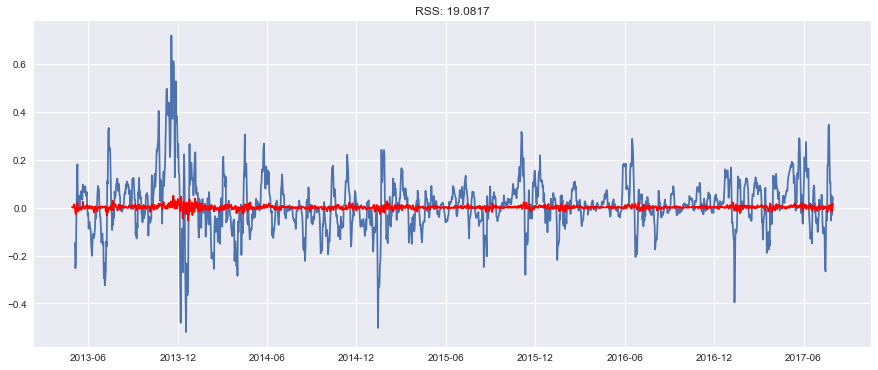

```python
model = ARIMA(ts_logtransformed, order=(0, 1,18))
results_MA = model.fit(disp=-1)
plt.plot(ts_diff_logtrans)
plt.plot(results_MA.fittedvalues, color='red')
RSS = results_MA.fittedvalues-ts_diff_logtrans
RSS.dropna(inplace=True)
plt.title('RSS: %.4f'% sum(RSS**2))
```

```python
#model summary
print(results_MA.summary())
```

```
                             ARIMA Model Results
==============================================================================
Dep. Variable:                D.Close   No. Observations:                 1555
Model:                ARIMA(0, 1, 18)   Log Likelihood                2727.323
Method:                       css-mle   S.D. of innovations              0.042
Date:                Wed, 07 Feb 2018   AIC                          -5414.646
Time:                        07:40:09   BIC                          -5307.661
Sample:                    04-29-2013   HQIC                         -5374.862
                         - 07-31-2017
==================================================================================
                     coef    std err          z      P>|z|      [0.025      0.975]
----------------------------------------------------------------------------------
const              0.0019      0.001      1.374      0.169      -0.001       0.005
ma.L1.D.Close     -0.0100      0.026     -0.390      0.697      -0.060       0.040
ma.L2.D.Close     -0.0373      0.025     -1.469      0.142      -0.087       0.012
ma.L3.D.Close     -0.0222      0.026     -0.871      0.384      -0.072       0.028
ma.L4.D.Close      0.0759      0.026      2.962      0.003       0.026       0.126
ma.L5.D.Close      0.0271      0.026      1.039      0.299      -0.024       0.078
ma.L6.D.Close      0.0821      0.026      3.142      0.002       0.031       0.133
ma.L7.D.Close     -0.0306      0.027     -1.151      0.250      -0.083       0.022
ma.L8.D.Close     -0.0069      0.026     -0.262      0.793      -0.058       0.045
ma.L9.D.Close     -0.0087      0.027     -0.326      0.745      -0.061       0.043
ma.L10.D.Close     0.0441      0.026      1.685      0.092      -0.007       0.095
ma.L11.D.Close     0.0772      0.025      3.047      0.002       0.028       0.127
ma.L12.D.Close    -0.0106      0.028     -0.381      0.703      -0.065       0.044
ma.L13.D.Close     0.0372      0.025      1.480      0.139      -0.012       0.086
ma.L14.D.Close     0.0325      0.028      1.147      0.251      -0.023       0.088
ma.L15.D.Close     0.0299      0.029      1.030      0.303      -0.027       0.087
ma.L16.D.Close     0.0025      0.027      0.091      0.927      -0.051       0.056
ma.L17.D.Close     0.0832      0.027      3.048      0.002       0.030       0.137
ma.L18.D.Close    -0.0335      0.028     -1.211      0.226      -0.088       0.021
                                    Roots
==============================================================================
                  Real           Imaginary           Modulus         Frequency
------------------------------------------------------------------------------
MA.1            -1.1293           -0.0000j            1.1293           -0.5000
MA.2            -1.0360           -0.4363j            1.1241           -0.4366
MA.3            -1.0360           +0.4363j            1.1241            0.4366
MA.4            -0.8723           -0.7427j            1.1457           -0.3877
MA.5            -0.8723           +0.7427j            1.1457            0.3877
MA.6            -0.5234           -0.9971j            1.1261           -0.3269
MA.7            -0.5234           +0.9971j            1.1261            0.3269
MA.8            -0.1031           -1.1561j            1.1607           -0.2642
MA.9            -0.1031           +1.1561j            1.1607            0.2642
MA.10            0.2555           -1.1746j            1.2020           -0.2159
MA.11            0.2555           +1.1746j            1.2020            0.2159
MA.12            0.6969           -0.9478j            1.1764           -0.1491
MA.13            0.6969           +0.9478j            1.1764            0.1491
MA.14            1.0915           -0.2689j            1.1242           -0.0384
MA.15            1.0915           +0.2689j            1.1242            0.0384
MA.16            0.9436           -0.6872j            1.1673           -0.1002
MA.17            0.9436           +0.6872j            1.1673            0.1002
MA.18            2.7060           -0.0000j            2.7060           -0.0000
------------------------------------------------------------------------------
```

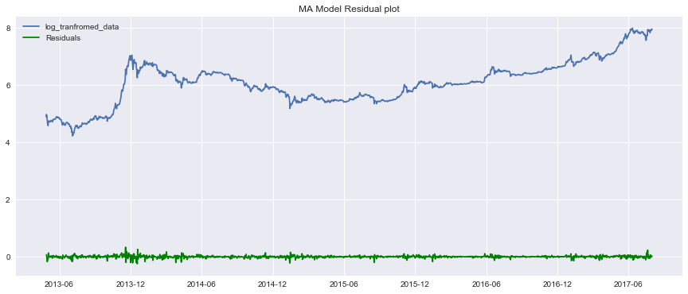

```python
plt.plot(ts_logtransformed, label = 'log_tranfromed_data')
plt.plot(results_MA.resid, color ='green',label= 'Residuals')
plt.title('MA Model Residual plot')
plt.legend(loc = 'best')
```

```
count    1555.000000
mean        0.000053
std         0.041911
min        -0.246817
25%        -0.013552
50%         0.000411
75%         0.015719
max         0.332676
dtype: float64
```

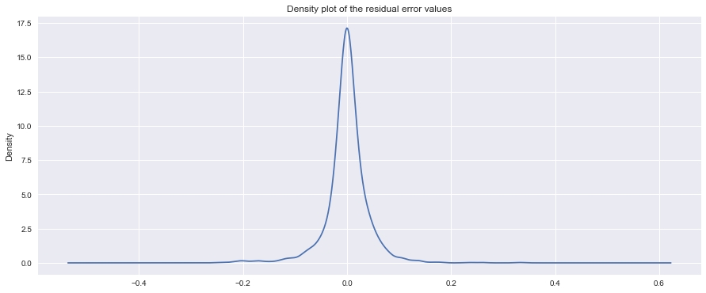

```python
results_MA.resid.plot(kind='kde')
plt.title('Density plot of the residual error values')
print(results_MA.resid.describe())
```